# Complex Network Analysis of Global Submarine Cable Systems: Structure, Communities and Vulnerability

2595695

2024-10-28

# 1.Research Background

Submarine cable networks carry 99% of intercontinental data transmission worldwide, demonstrating their vital role in global information infrastructure(Franken, Reinhold, Reichert, & Reuter, 2022). These networks not only influence the development of the global digital economy but also shape the evolution of international communications patterns. According to [TeleGeography’s statistics](https://blog.telegeography.com/how-many-submarine-cables-are-there-anyway), By the beginning of 2024, the total length of global submarine cables exceeds 1.4 million kilometers, which is one of the main media for contemporary global information transmission.

While previous studies have examined the technical aspects and economic implications of submarine cables (Wang et al., 2021), understanding their network properties becomes increasingly important. Studies show that approximately 70% of submarine cable faults result from external aggression primarily associated with human activities (such as shipping, fishing, and anchoring). Furthermore, 75% of submarine cable faults occur in shallow waters below 200m due to fishing and shipping activities (Msongaleli, Dikbiyik, Zukerman, & Mukherjee, 2015). Although failures caused by natural disasters account for less than 10% of all faults (occurring in both deep and shallow waters), when focusing on deep-water cables, at least 31% of submarine cable failures are attributed to natural disasters (Msongaleli et al., 2015). These statistics suggest that while efforts to address submarine cable failures have concentrated on eliminating human-caused faults, less attention has been paid to other causes, highlighting the need for a comprehensive understanding of network vulnerability.

# 2.Research Question

This study will explore the topology of the global submarine cable network by analyzing 144 international submarine cables connecting 129 countries. The importance of different countries in the network,and are there obvious regional communication clusters in the network? What kind of connectivity patterns do these clusters reflect? How will the failure of critical nodes affect the network connectivity? What factors influence the strength of cable connections between countries? By exploring these issues, this study will reveal the structural characteristics of the global submarine cable network and its far-reaching impact on the international communication landscape. It has important theoretical and practical significance for assessing the vulnerability of global communication systems, optimizing network layout and formulating relevant policies.

# 3.Data sources and Research Method

## 3.1 Data sources and processing

In terms of specific data processing and network construction, geometric information is used to connect and match the three datasets, and invalid values are removed. Set the same coordinate reference frame. In addition, due to the special topology of submarine cable, every two nodes have a direct connection of information flow. This study considers all nodes on the same cable as direct connections, so it is necessary to create country pairs, delete cable data connected between the same country, create bilateral connections for multi-country cables, and calculate the edge weight by the number of cables. Finally,building network graph structure.

## 3.2.Research Method

This study employs a comprehensive network analysis approach to examine the global submarine cable infrastructure. The methodology combines complex network analysis, spatial statistics, and vulnerability assessment to understand the structural characteristics and vulnerability of the global submarine cable network. Firstly, the network scale structure and the topological structure characteristics of the global submarine cable network were analyzed, and the global submarine cable was viewed from a macro perspective.

In addition, centrality analysis can analyze which countries play an important role in the global submarine cable network. This research focus on weighted degree centrality and betweenness centrality analysis. Degree centrality measures the number and connection strength of other countries that a country is directly connected to. High centrality means that a country has direct cable connections with multiple countries, reflecting its direct influence in the global communication network, while weight reflects the number of repeated cable connections between countries. Weighted degree centrality can comprehensively reflect the influence of countries on cable connections. Betweenness centrality analysis can measure how often a country acts as a transit station on the shortest path between pairs of other countries, identifying critical transit countries, and high betweenness centrality indicates that the country frequently acts as a communication transit station. This comprehensive analysis method comprehensively reflects the network structure and provides a multi-dimensional evaluation framework.

Because submarine cables are easily to damage due to natural disasters or human impacts and have high maintenance costs, especially in today’s digital age, they are important to global communications and the economy. So this study used vulnerability analysis, which simulated how the connectivity and average path length of a node changed when it was attacked, to identify the critical infrastructure that needed the most protection.(Jenelius & Mattsson, 2015) (章卓凡, 张维阳, 翟庆华, 钱雨昕, & 陈硕, 2022)

## 3.3.Data Presentation

```r
# Load packages
library(sf)
library(kableExtra)
library(igraph)
library(knitr)
library(corrplot)
library(tidyverse)
library(geojsonio)
library(stplanr)
library(leaflet)
library(rprojroot)
library(dplyr)
library(tmap)
library(ggplot2)
library(gridExtra)
```

```r
# Download the cable data and save it as cables.geojson
download.file("https://web.archive.org/web/20220325095548/https:/raw.githubusercontent.com/telegeography/www.submarinecablemap.com/master/web/public/api/v3/cable/cable-geo.json",
              destfile = "data/cables.geojson")

# Download the landing points data and save it as points.geojson
download.file("https://web.archive.org/web/20220325095548/https:/raw.githubusercontent.com/telegeography/www.submarinecablemap.com/master/web/public/api/v3/landing-point/landing-point-geo.json",
              destfile = "data/points.geojson")
```

```r
# Read the cables data
cables <- st_read("data/cables.geojson")

# Read the landing points data
points <- st_read("data/points.geojson")
```

```r
# Check the cables data
x_html <- knitr:: kable(head(cables), "html", caption = "Table 1.Global submarine cables data")
kableExtra::kable_styling(x_html,bootstrap_options = "striped",
 full_width = 200,position = "left")
```

Table 1.Global submarine cables data

| id | name | color | feature_id | coordinates | geometry |
| --- | --- | --- | --- | --- | --- |
| sea-h2x | SEA-H2X | #939597 | sea-h2x-0 | 111.34949, 10.19538 | MULTILINESTRING ((113.85 17… |
| hronn | Hronn | #009f94 | hronn-0 | 6.459456, 55.375968 | MULTILINESTRING ((5.40007 5… |
| cook-strait | Cook Strait | #951f63 | cook-strait-0 | 174.43018, -41.37029 | MULTILINESTRING ((174.236 -… |
| minoas-east-and-west | Minoas East and West | #939597 | minoas-east-and-west-0 | 23.66363, 35.66560 | MULTILINESTRING ((23.03575 … |
| apollo-east-and-west | Apollo East and West | #939597 | apollo-east-and-west-0 | 24.84719, 35.48642 | MULTILINESTRING ((23.36324 … |
| seamewe-6 | SeaMeWe-6 | #939597 | seamewe-6-0 | 68.05747, 14.81613 | MULTILINESTRING ((65.75492 … |

```r
# Check the landing points data
x_html <- knitr:: kable(head(points), "html",caption = "Table 2.landing points data")
kableExtra::kable_styling(x_html,bootstrap_options = "striped",
 full_width = T)
```

Table 2.landing points data

| id | name | is_tbd | geometry |
| --- | --- | --- | --- |
| changi-south-singapore | Changi South, Singapore | FALSE | POINT (103.987 1.389045) |
| la-union-philippines | La Union, Philippines | FALSE | POINT (120.3209 16.61589) |
| mersing-malaysia | Mersing, Malaysia | FALSE | POINT (103.8499 2.295733) |
| kuching-malaysia | Kuching, Malaysia | FALSE | POINT (110.3537 1.520195) |
| tuas-singapore | Tuas, Singapore | FALSE | POINT (103.6462 1.338646) |
| songkhla-thailand | Songkhla, Thailand | FALSE | POINT (100.597 7.078559) |

This imageFig.1 displays the global submarine cable routes and their associated landing points. Regions such as Europe, the Middle East, and East Asia exhibit dense networks of cables and landing points. In contrast, areas like parts of Africa and the Pacific show fewer connections, reflecting lower connectivity or dependence on a smaller number of cable systems.

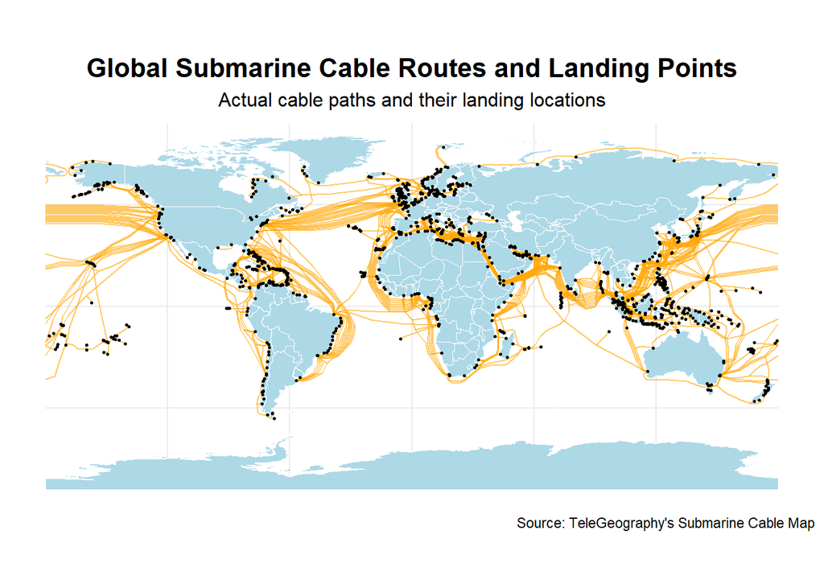

```r
library(rnaturalearth)
library(rnaturalearthdata)
# loding accurate world map from returnclass package
world <- ne_countries(scale = "medium", returnclass = "sf")
# Create actual cable routes map
ggplot() +
  # Add base map (countries)
  geom_sf(data = world,
          fill = "lightblue",
          color = "white") +
  # Add actual cable routes
  geom_sf(data = cables,
          color = "orange",
          size = 0.5,
          alpha = 0.6) +
  # Add landing points
  geom_sf(data = points,
          size = 0.5,
          color = "black") +
  # Theme and labels
  theme_minimal() +
  labs(
    title = "Global Submarine Cable Routes and Landing Points",
    subtitle = "Actual cable paths and their landing locations",
    caption = "Source: TeleGeography's Submarine Cable Map"
  ) +
  theme(
    plot.title = element_text(hjust = 0.5, size = 16, face = "bold"),
    plot.subtitle = element_text(hjust = 0.5, size = 12),
    legend.position = "none",
    axis.text = element_blank(),
    axis.ticks = element_blank()
  ) +
  coord_sf(crs = st_crs(4326))
```

Fig.1.Global Submarine Cable Routes and Landing Points

From this website [Access to global administrative boundaries](https://www.geoboundaries.org/globalDownloads.html)get countries boundaries data.

```r
# loading geo_boundaries data
file_path <- "./data/geoBoundariesCGAZ_ADM0.geojson"
geo_boundaries <- st_read(file_path)
```

## 3.4.Data processing

```r
#Ensure Consistent Coordinate Reference Systems (CRS)
# Transform landing points to match countries' CRS
points <- st_transform(points, st_crs(geo_boundaries))
# Transform cables to match countries' CRS
cables <- st_transform(cables, st_crs(geo_boundaries))
```

```r
# Check which geometries are invalid
invalid_geometries <- st_is_valid(geo_boundaries)
print(table(invalid_geometries))  # Count valid and invalid geometries
```

```
## invalid_geometries
## FALSE  TRUE
##     3   215
```

From the checking result, the geo_boundaries dataset contains 3 invalid geometric information, these invalid geometric information may lead to the next spatial connection problem.

```r
#Correct invalid geometries(might arise due to issues like self-intersecting polygons or missing coordinates) in the dataset.
#fix any invalid geometries
geo_boundaries <- st_make_valid(geo_boundaries)
```

```r
# Check which geometries are valid
invalid_geometries <- st_is_valid(geo_boundaries)
# Summarize the number of valid and invalid geometries
print(table(invalid_geometries))
```

```
## invalid_geometries
## TRUE
##  218
```

```r
#Matches each point to its corresponding country boundary using a spatial join.
#join points and country boundary data
points_with_country <- st_join(points, geo_boundaries["shapeName"])
head(points_with_country)
```

```
## Simple feature collection with 6 features and 4 fields
## Geometry type: POINT
## Dimension:     XY
## Bounding box:  xmin: 100.597 ymin: 1.338646 xmax: 120.3209 ymax: 16.61589
## Geodetic CRS:  WGS 84
##                       id                    name is_tbd   shapeName
## 1 changi-south-singapore Changi South, Singapore  FALSE   Singapore
## 2   la-union-philippines   La Union, Philippines  FALSE Philippines
## 3       mersing-malaysia       Mersing, Malaysia  FALSE    Malaysia
## 4       kuching-malaysia       Kuching, Malaysia  FALSE    Malaysia
## 5         tuas-singapore         Tuas, Singapore  FALSE   Singapore
## 6      songkhla-thailand      Songkhla, Thailand  FALSE    Thailand
##                    geometry
## 1  POINT (103.987 1.389045)
## 2 POINT (120.3209 16.61589)
## 3 POINT (103.8499 2.295733)
## 4 POINT (110.3537 1.520195)
## 5 POINT (103.6462 1.338646)
## 6  POINT (100.597 7.078559)
```

```r
#Quantifies the points that could not be matched to any country.
#check the number of missing values
na_count <- sum(is.na(points_with_country$shapeName))
print(paste("Number of unmatched points:", na_count))
```

```
## [1] "Number of unmatched points: 163"
```

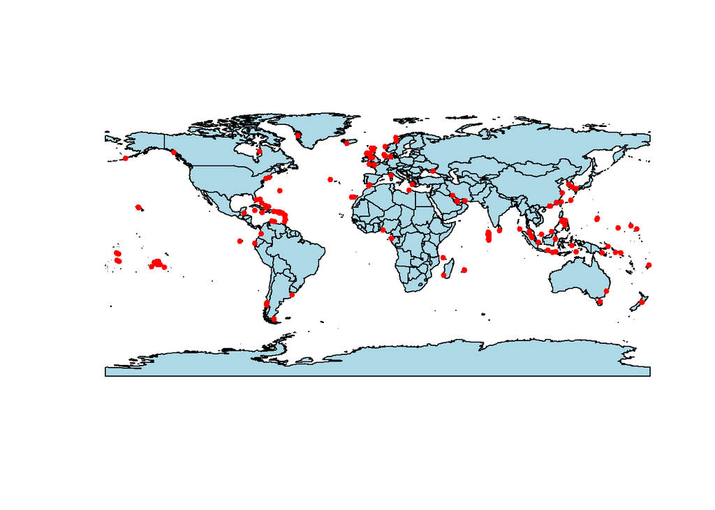

```r
library(rnaturalearth)
library(rnaturalearthdata)
# loding accurate world map from returnclass package
world <- ne_countries(scale = "medium", returnclass = "sf")
unmatched_points <- points_with_country %>%
  filter(is.na(shapeName))

plot(st_geometry(world), col = "lightblue", reset = FALSE)
plot(st_geometry(unmatched_points), col = "red", pch = 20, add = TRUE)
```

Fig.2.Visualisation of missing data in spatial connectivity.

As shown inFig.2, I found that 163 out of 1,335 landing points (12.2%) couldn’t be matched to any country in our dataset. These unmatched points were mostly located just outside country borders or in offshore areas. Through careful checking, I found that these are typically additional landing points for cables that we’ve already captured through other matched points in our dataset. This means that even without these points, we still maintain the essential cable connections between countries in our network structure.

```r
# Remove missing values and modify the original variable directly
points_with_country <- points_with_country %>%
  filter(!is.na(shapeName))
```

```r
#match the cables and points_with_country data
cable_point_matches <- points_with_country %>%
  filter(!is.na(shapeName)) %>%
  st_join(
    cables,
    join = st_nearest_feature,
    multiple = TRUE
  ) %>%
  select(
    cable_id = id.y,
    cable_name = name.y,
    point_id = id.x,
    point_name = name.x,
    country = shapeName,
    geometry
  )
```

```r
# Check cable and state connections
print("check the number of countries connected by each cable：")
```

```
## [1] "check the number of countries connected by each cable："
```

```r
cable_point_matches %>%
  group_by(cable_id) %>%
  summarise(
    num_countries = n_distinct(country),
    countries = paste(sort(unique(country)), collapse = ", ")
  ) %>%
  arrange(desc(num_countries)) %>%
  head(10)
```

```
## Simple feature collection with 10 features and 3 fields
## Geometry type: MULTIPOINT
## Dimension:     XY
## Bounding box:  xmin: -87.94607 ymin: -33.9625 xmax: 121.4726 ymax: 51.23112
## Geodetic CRS:  WGS 84
## # A tibble: 10 × 4
##    cable_id                    num_countries countries                  geometry
##    <chr>                               <int> <chr>              <MULTIPOINT [°]>
##  1 2africa                                22 Angola, … ((-15.59657 27.95773), (…
##  2 africa-coast-to-europe-ace             11 Benin, C… ((-15.97828 18.08387), (…
##  3 arcos                                   9 Colombia… ((-80.16238 25.93294), (…
##  4 eastern-caribbean-fiber-sy…             8 Antigua … ((-63.05721 18.21741), (…
##  5 seamewe-3                               8 Belgium,… ((-9.102751 38.44269), (…
##  6 gulf-bridge-international-…             6 Bahrain,… ((51.45189 25.53859), (5…
##  7 seamewe-4                               6 India, I… ((9.867352 37.27635), (1…
##  8 southern-caribbean-fiber                6 Antigua … ((-66.10667 18.46584), (…
##  9 asia-africa-europe-1-aae-1              5 Burma, C… ((29.70249 31.07185), (9…
## 10 europe-india-gateway-eig                5 Djibouti… ((-5.347676 36.15594), (…
```

Submarine cables connect multiple landing points across different countries. To analyze international connections, we identified cables linking different countries and filtered out domestic cables. This organizes the data to show which countries are connected by each cable.

```r
# Create groups of submarine cables with their connected countries
cable_country_groups <- cable_point_matches %>%
  group_by(cable_id, cable_name) %>%
  summarise(
    countries = list(sort(unique(country))),
    num_countries = n_distinct(country)
  )
head(cable_country_groups)
```

```
## Simple feature collection with 6 features and 4 fields
## Geometry type: GEOMETRY
## Dimension:     XY
## Bounding box:  xmin: -151.5443 ymin: -33.9625 xmax: 56.33998 ymax: 61.21746
## Geodetic CRS:  WGS 84
## # A tibble: 6 × 5
## # Groups:   cable_id [6]
##   cable_id          cable_name countries num_countries                  geometry
##   <chr>             <chr>      <list>            <int>            <GEOMETRY [°]>
## 1 2africa           2Africa    <chr>                22 MULTIPOINT ((-15.59657 2…
## 2 acs-alaska-orego… ACS Alask… <chr [1]>             1 MULTIPOINT ((-124.0998 4…
## 3 aden-djibouti     Aden-Djib… <chr [1]>             1 POINT (43.14583 11.59874)
## 4 adria-1           Adria-1    <chr [3]>             3 MULTIPOINT ((18.10641 42…
## 5 africa-1          Africa-1   <chr [2]>             2 MULTIPOINT ((43.24733 13…
## 6 africa-coast-to-… Africa Co… <chr>                11 MULTIPOINT ((-15.97828 1…
```

These cables need to be removed before network analysis, as our purpose is to study the connection relationships between nodes (countries). Cables that only connect points within a single country cannot form international connection relationships (edges). Since these single-country cables are purely for domestic communication, they would not contribute to our analysis of international network connectivity.

```r
# Remove cables that only connect to one country
cable_country_groups_filtered <- cable_country_groups %>%
  filter(num_countries >= 2)

# Check the filtering results
print("Before filtering:")
```

```
## [1] "Before filtering:"
```

```r
print(paste("Total cables:", nrow(cable_country_groups)))
```

```
## [1] "Total cables: 418"
```

```r
print(paste("Cables with single country:", sum(cable_country_groups$num_countries == 1)))
```

```
## [1] "Cables with single country: 274"
```

```r
print("\nAfter filtering:")
```

```
## [1] "\nAfter filtering:"
```

```r
print(paste("Remaining cables:", nrow(cable_country_groups_filtered)))
```

```
## [1] "Remaining cables: 144"
```

```r
# Calculate total number of unique countries in the network
total_countries <- cable_country_groups_filtered %>%
  unnest(countries) %>%
  pull(countries) %>%
  unique() %>%
  length()
```

From the results, there are a total of 418 submarine cables, of which 274 cables connect only one country and 144 cables connect multiple countries. So most of the undersea cables are domestic cables. Only about a third of the cables are international, and these are the ones we really need to focus on in our network analysis.

Due to the particularity of the submarine cable network, all countries on the same cable can directly exchange information with each other, so we need to create country pairs to represent this direct connection relationship.

```r
# Create all possible country pairs connected by each cable
network_edges <- cable_country_groups_filtered %>%
  unnest(countries) %>%
  group_by(cable_id) %>%
# Create all possible country pairs for each cable
  summarise(
    country_pairs = list(t(combn(unique(countries), 2))),
    .groups = "drop"
  ) %>%
  unnest(country_pairs) %>%
  # Create the final edge list with from-to format
  transmute(
    from = country_pairs[,1],
    to = country_pairs[,2]
  )
```

# 4.network analysis

## 4.1.Analyse the basic size of submarine cable networks.

```r
# Basic size of computing networks
network_stats <- list(
  total_nodes = cable_country_groups_filtered %>%
    unnest(countries) %>%
    pull(countries) %>%
    unique() %>%
    length(),

  total_cables = cable_country_groups_filtered %>%
    nrow()
)

# Calculate the number of actual edges
edge_stats <- network_edges %>%
  summarise(
    total_edges = n(),
    unique_edges = n_distinct(paste(pmin(from, to), pmax(from, to)))
  )

# print basic information
print("Basic size of the network:")
```

```
## [1] "Basic size of the network:"
```

```r
print(paste("Number of nodes (total number of unique countries):", network_stats$total_nodes))
```

```
## [1] "Number of nodes (total number of unique countries): 129"
```

```r
print(paste("total cables:", network_stats$total_cables))
```

```
## [1] "total cables: 144"
```

```r
print(paste("total edges:", edge_stats$total_edges))
```

```
## [1] "total edges: 681"
```

```r
print(paste("unique edges:", edge_stats$unique_edges))
```

```
## [1] "unique edges: 591"
```

Taking the number of cable connections as weights, a table containing the starting point, end point and weight of the cable is calculated.

```r
# Calculate weights based on connections between country pairs
weighted_edges <- network_edges %>%
  # just choose from and to
  select(from, to) %>%
  # Ensure consistent direction
  mutate(
    from_norm = pmin(from, to),
    to_norm = pmax(from, to)
  ) %>%
  # Calculate weights
  group_by(from_norm, to_norm) %>%
  summarise(
    weight = n(),
    .groups = "drop"
  ) %>%
  # Restore column names
  rename(from = from_norm, to = to_norm)

# Check the result - should only have 3 columns: from, to, weight
print(head(weighted_edges))
```

```
## Simple feature collection with 6 features and 3 fields
## Geometry type: MULTIPOINT
## Dimension:     XY
## Bounding box:  xmin: -9.150192 ymin: 35.07141 xmax: 24.76828 ymax: 42.64186
## Geodetic CRS:  WGS 84
## # A tibble: 6 × 4
##   from    to       weight                                               geometry
##   <chr>   <chr>     <int>                                       <MULTIPOINT [°]>
## 1 Albania Croatia       1 ((18.10641 42.64186), (19.45006 41.31669), (19.91949 …
## 2 Albania Greece        1 ((18.10641 42.64186), (19.45006 41.31669), (19.91949 …
## 3 Algeria Greece        1 ((-5.391813 35.56591), (-5.843848 36.13476), (-5.2751…
## 4 Algeria Morocco       1 ((-5.391813 35.56591), (-5.843848 36.13476), (-5.2751…
## 5 Algeria Portugal      1 ((-5.391813 35.56591), (-5.843848 36.13476), (-5.2751…
## 6 Algeria Spain         2 ((-5.391813 35.56591), (-5.843848 36.13476), (-5.2751…
```

After obtaining the country pairs from the dataset, we will now convert the country pairs (weighted_edges) into spatial data to facilitate visualization.

```r
# Create spatial lines with weights
edges_sf_lines <- weighted_edges %>%
  # Add coordinates for starting points (from country centers)
  left_join(
    st_coordinates(st_centroid(geo_boundaries)) %>%
    as.data.frame() %>%
    cbind(country = geo_boundaries$shapeName),
    by = c("from" = "country")
  ) %>%
  # Add coordinates for ending points (to country centers)
  left_join(
    st_coordinates(st_centroid(geo_boundaries)) %>%
    as.data.frame() %>%
    cbind(country = geo_boundaries$shapeName),
    by = c("to" = "country")
  ) %>%
  # Create LINESTRING geometry
  mutate(geometry = map2(
    map2(X.x, Y.x, ~c(.x, .y)),
    map2(X.y, Y.y, ~c(.x, .y)),
    ~st_linestring(matrix(c(.x, .y), ncol=2, byrow=TRUE))
  ) %>%
    st_sfc(crs = st_crs(geo_boundaries))
  ) %>%
  st_sf()
# Check the result
print(head(edges_sf_lines))
```

```
## Simple feature collection with 6 features and 7 fields
## Geometry type: LINESTRING
## Dimension:     XY
## Bounding box:  xmin: -8.559853 ymin: 28.05719 xmax: 22.99083 ymax: 45.03677
## Geodetic CRS:  WGS 84
## # A tibble: 6 × 8
##   from    to       weight                       geometry   X.x   Y.x   X.y   Y.y
##   <chr>   <chr>     <int>               <LINESTRING [°]> <dbl> <dbl> <dbl> <dbl>
## 1 Albania Croatia       1 (20.06821 41.13161, 16.40366 … 20.1   41.1 16.4   45.0
## 2 Albania Greece        1 (20.06821 41.13161, 22.99083 … 20.1   41.1 23.0   39.0
## 3 Algeria Greece        1 (2.687552 28.05719, 22.99083 …  2.69  28.1 23.0   39.0
## 4 Algeria Morocco       1 (2.687552 28.05719, -6.356474…  2.69  28.1 -6.36  31.8
## 5 Algeria Portugal      1 (2.687552 28.05719, -8.559853…  2.69  28.1 -8.56  39.6
## 6 Algeria Spain         2 (2.687552 28.05719, -3.705156…  2.69  28.1 -3.71  40.2
```

Fig.3 shows the spatial mapping of the global submarine cable network. From the figure,we can see that submarine cable networks are very dense in parts of Europe, the Middle East, and East Asia. However, the global distribution of submarine cables is noticeably uneven, with inland countries or less developed regions having significantly fewer connections in comparison.

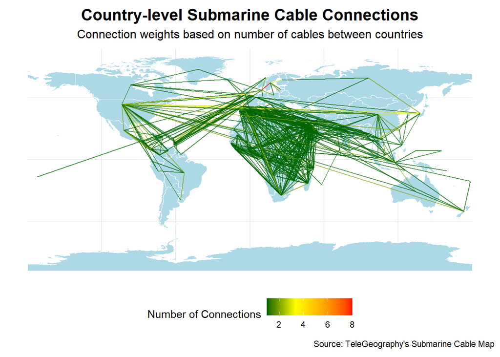

```r
# Create the map visualization
ggplot() +
  # Add base map
  geom_sf(data = world,
          fill = "lightblue",
          color = "white") +
  # Add weighted connections
  geom_sf(data = edges_sf_lines,
          aes(color = weight),
          alpha = 0.7) +
  # Color scale
  scale_color_gradientn(
    colors = c("darkgreen", "yellow", "orange", "red"),
    name = "Number of Connections",
    breaks = c(2, 4, 6, 8),
    limits = c(1, 8)
  ) +
  # Size scale
  scale_size_continuous(
    name = "Number of Connections",
    range = c(0.3, 2),
    breaks = c(2, 4, 6, 8)
  ) +
  # Theme and labels
  theme_minimal() +
  labs(
    title = "Country-level Submarine Cable Connections",
    subtitle = "Connection weights based on number of cables between countries",
    caption = "Source: TeleGeography's Submarine Cable Map"
  ) +
  theme(
    plot.title = element_text(hjust = 0.5, size = 16, face = "bold"),
    plot.subtitle = element_text(hjust = 0.5, size = 12),
    legend.position = "bottom",
    legend.box = "vertical",
    axis.text = element_blank(),
    axis.ticks = element_blank()
  ) +
  coord_sf(crs = st_crs(4326))
```

Fig.3. Country-level Submarine Cable Connections

```r
# Create igraph object from weighted edges
network_graph <- graph_from_data_frame(
  d = weighted_edges %>% select(from, to, weight),
  directed = FALSE
)
```

However, due to the large number of nodes and edges, visual analysis is quite challenging, making it difficult to precisely analyze the exact scale of the network. Therefore, it is very necessary to use mathematical network parameters, as shown in [Table 3].

Based on the data in [Table 3], the network consists of 129 nodes (countries) and 591 edges (submarine cables and cable branches). The largest connected component includes all 129 nodes, indicating that the network has good connectivity. The edge density (the ratio of the actual number of connections to the possible maximum number of connections in the network) is only 7.16%, which means that the network is very loose and most nodes are not directly connected to each other. The average path length is 3.44 edges, indicating a relatively high level of connectivity across the network. The maximum diameter is 10 edges, meaning that even the farthest countries are at most separated by ten cables.

One notable feature of the submarine cable network, unlike other networks, is its low edge density. This results from the geographical challenges of laying submarine cables, which requires significant effort and high costs. Moreover, international laws and maritime regulations can hinder cable deployment, and countries tend to prioritize connections with key economic partners or allies, leading to reduced overall edge density (McGeachy, 2022). Additionally, technical limitations in cable design and data transmission contribute to the network’s sparse connections (Kang, Ma, Feng, Shao, & Ma, 2024). Overall, the network shows a characteristic of tight local connections while being loosely connected as a whole.

```r
# Create table for display
metrics_table <- data.frame(
   Metric = c("Nodes (V)",
             "Edges (E)",
             "Largest Component",
             "Δ(G)",
             "Edge Density",
             "Average Path Length",
             "Diameter",
             "Largest Clique"),
  Value = c(network_properties$V,
            network_properties$E,
            network_properties$largest_component,
            network_properties$max_degree,
            sprintf("%.4f", network_properties$edge_density),
            sprintf("%.2f", network_properties$avg_distance),
            paste(network_properties$diameter, "edges"),
            paste(network_properties$max_clique, "nodes"))
)

# Check the data frame
print(metrics_table)
```

```
##                Metric    Value
## 1           Nodes (V)      129
## 2           Edges (E)      591
## 3   Largest Component      129
## 4                Δ(G)       47
## 5        Edge Density   0.0716
## 6 Average Path Length     3.44
## 7            Diameter 10 edges
## 8      Largest Clique 22 nodes
```

```r
# Load required libraries
library(knitr)
library(kableExtra)

# Create formatted table
kable(metrics_table,
      caption = "Table 3.General Properties of Network Model",
      col.names = c("Metric", "Value"),
      align = c("l", "r")) %>%
  kable_styling(bootstrap_options = c("striped", "hover"))
```

Table 3.General Properties of Network Model

| Metric | Value |
| --- | --- |
| Nodes (V) | 129 |
| Edges (E) | 591 |
| Largest Component | 129 |
| Δ(G) | 47 |
| Edge Density | 0.0716 |
| Average Path Length | 3.44 |
| Diameter | 10 edges |
| Largest Clique | 22 nodes |

## 4.2 Identify central nodes by centrality index

Centrality measures in network analysis can assess whether edges and nodes are positioned at the center of paths, helping to evaluate the importance of a node(Marzo, Calle, Cosgaya, Rueda, & Mañosa, 2018). Betweenness centrality measures a country’s role as a transit point, specifically its ability to pass information between other countries in the network. The higher a node’s betweenness centrality, the greater its ability to control the flow of information across the network(章卓凡 et al., 2022).

Based on the analysis results in Fig.4 and Table 4, France and the United States lead in both centrality rankings, demonstrating their role as key hubs in the global communication network. Their advanced economies and technologies allow them to build more complex and redundant communication networks. Historically, the early establishment of transatlantic cables by the United States and other European countries also laid the foundation for their central positions in the global communication network(Ganz et al., 2024).In terms of weighted degree centrality, countries like South Africa, Spain, and Italy follow closely behind, occupying leading positions within their respective regions. Egypt also ranks highly, which can be attributed to its strategic location. As a key transit country connecting Europe and East Asia, Egypt’s high centrality reflects the crucial role of the Suez Canal in the global communication network. In terms of betweenness centrality, countries like Spain, the Netherlands, and Denmark have high values, indicating that they are not only important parts of their regional networks but also likely serve as key transit points for interregional communication.

Comparing Fig.4, countries like Qatar and the UAE show high degree centrality but have relatively low betweenness centrality. This is because these countries have many direct submarine cable connections, which primarily serve the Middle East region. On the other hand, countries like the Netherlands, Japan, and Denmark, although ranking lower in degree centrality, rank higher in betweenness centrality. This indicates that their geographic location or strategic role makes them important bridges for communication flow. The Netherlands, in particular, has a favorable location as the “gateway to Europe,” acting as a hub for communication between Europe and other continents.

```r
# Calculate two centrality metrics
centrality_df <- data.frame(
 country = V(network_graph)$name,
 weighted_degree = strength(network_graph),
 betweenness = betweenness(network_graph, normalized = TRUE)
) %>%
 # Round numbers to 4 decimal places
 mutate(betweenness = round(betweenness, 4))

# Get top 20 countries (sorted by each metric)
top_20_strength <- centrality_df %>%
 arrange(desc(weighted_degree)) %>%
 head(20)

top_20_betweenness <- centrality_df %>%
 arrange(desc(betweenness)) %>%
 head(20)
```

```r
# Create top_20_strength table
kable(top_20_strength,
      caption = "Table 4. Top 20 Countries by Weighted Degree Centrality",
      col.names = c("country", "weighted_degree","betweenness"),
      align = c("l", "r")) %>%
  kable_styling(bootstrap_options = c("striped", "hover"))
```

Table 4. Top 20 Countries by Weighted Degree Centrality

|  | country | weighted_degree | betweenness |
| --- | --- | --- | --- |
| France | France | 62 | 0.3363 |
| United States | United States | 50 | 0.2237 |
| Italy | Italy | 37 | 0.0421 |
| South Africa | South Africa | 37 | 0.1452 |
| Spain | Spain | 34 | 0.1583 |
| Portugal | Portugal | 32 | 0.0988 |
| United Kingdom | United Kingdom | 32 | 0.0449 |
| Egypt | Egypt | 28 | 0.0269 |
| Qatar | Qatar | 27 | 0.0148 |
| United Arab Emirates | United Arab Emirates | 27 | 0.0148 |
| Bahrain | Bahrain | 26 | 0.0148 |
| Somalia | Somalia | 26 | 0.0449 |
| Angola | Angola | 24 | 0.0053 |
| Kuwait | Kuwait | 24 | 0.0119 |
| Madagascar | Madagascar | 24 | 0.0002 |
| China | China | 23 | 0.0369 |
| Kenya | Kenya | 22 | 0.0015 |
| Congo, Dem Rep of the | Congo, Dem Rep of the | 21 | 0.0054 |
| Congo, Rep of the | Congo, Rep of the | 21 | 0.0054 |
| Ghana | Ghana | 21 | 0.0054 |

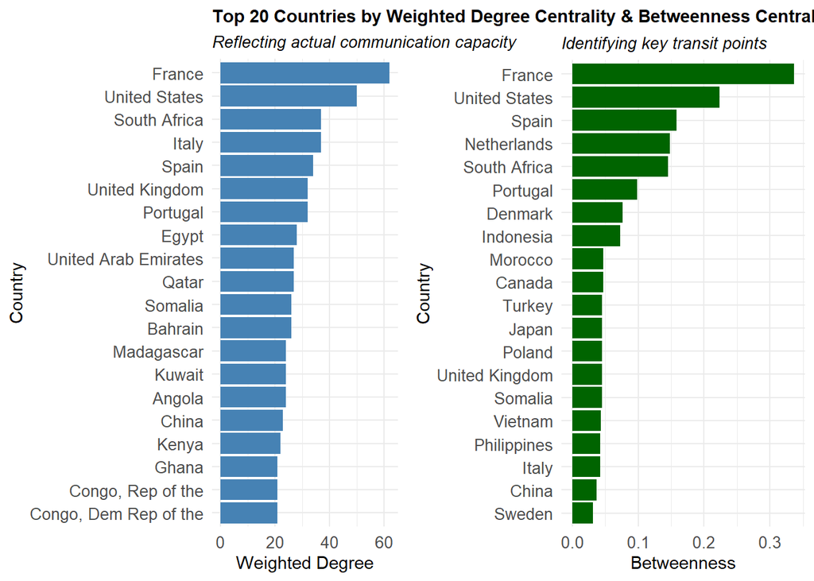

```r
# Bar plot for Weighted Degree Centrality
p1 <- ggplot(top_20_strength, aes(x = reorder(country, weighted_degree), y = weighted_degree)) +
 geom_bar(stat = "identity", fill = "steelblue") +
 coord_flip() +
 theme_minimal() +
 labs(
   title = "Top 20 Countries by Weighted Degree Centrality & Betweenness Centrality",
   subtitle = "Reflecting actual communication capacity",
   x = "Country",
   y = "Weighted Degree"
 ) +
 theme(
   plot.title = element_text(size = 11, face = "bold"),
   plot.subtitle = element_text(size = 10, face = "italic"),
   axis.text = element_text(size = 10)
 )

# Bar plot for Betweenness Centrality
p2 <- ggplot(top_20_betweenness, aes(x = reorder(country, betweenness), y = betweenness)) +
 geom_bar(stat = "identity", fill = "darkgreen") +
 coord_flip() +
 theme_minimal() +
 labs(
   title = " ",
   subtitle = "Identifying key transit points",
   x = "Country",
   y = "Betweenness"
 ) +
 theme(
   plot.title = element_text(size = 12, face = "bold"),
   plot.subtitle = element_text(size = 10, face = "italic"),
   axis.text = element_text(size = 10)
 )

# Display plots side by side
grid.arrange(p1, p2, ncol = 2)
```

Fig.4.Top 20 Countries by Weighted Degree Centrality & Betweenness Centrality

## 4.3 Community dectation

Community detection can help identify key nodes and potential weak areas in the network, while revealing whether there is a clustering effect of geographical areas in the network. For example, with community detection, we can find out whether certain geographic regions form independent connected groups. A community may be more vulnerable in the network if it is isolated and has fewer connecting paths with other communities. Once a break occurs, the whole community may be at risk of communication disruption.

In this study, a community detection analysis of the submarine cable network using the Fast Greedy algorithm revealed a unique community structure with a modularity score of 0.5176, which indicates the presence of a clustering pattern in the network. The algorithm divides the network into seven different communities of various sizes, each ranging from 5 to 40 countries.

What I find particularly interesting is that these communities are not determined by geographic proximity alone. While countries in the same region often belong to the same community, as shown by the Asian and European clusters, there are also links that transcend purely geographical boundaries. This indicates that factors such as economic ties, historical relations and strategic partnerships play a crucial role in shaping the structure of submarine cable networks(Ganz et al., 2024).

The level of connectivity varies across regions, indicating the potential for network expansion. This knowledge may be valuable for network planning and risk assessment, helping to identify where additional connections may be needed to enhance network resilience.

```r
# Community Detection using Fast Greedy method
communities <- cluster_fast_greedy(network_graph)

# Get modularity score
modularity_score <- modularity(communities)
print(paste("Network Modularity Score:", round(modularity_score, 4)))
```

```
## [1] "Network Modularity Score: 0.5176"
```

```r
# Get community sizes
community_sizes <- sizes(communities)
print(community_sizes)
```

```
## Community sizes
##  1  2  3  4  5  6  7
## 28 29 40  9 10  5  8
```

```r
# Create a data frame with community assignments
community_df <- data.frame(
  country = V(network_graph)$name,
  community = communities$membership
) %>%
  arrange(community)
```

when joining the “name” column in the world dataset with the “country” column in community_df, many countries did not match. This inconsistency in country names led to missing data in the subsequent analysis. Therefore, the country names in the world dataset were adjusted to match the format used in the original submarine cable data.

```r
world_communities <- world %>%
  mutate(
    join_name = case_when(
      # Basic name variations
      name == "South Korea" ~ "Korea, South",
      name == "Antigua and Barb." ~ "Antigua & Barbuda",
      name == "St. Vin. and Gren." ~ "St Vincent & the Grenadines",
      name == "Eq. Guinea" ~ "Equatorial Guinea",
      name == "Trinidad and Tobago" ~ "Trinidad & Tobago",
      name == "United States of America" ~ "United States",
      name == "Myanmar" ~ "Burma",
      name == "São Tomé and Principe" ~ "Sao Tome & Principe",
      name == "Bahamas" ~ "Bahamas, The",
      name == "Gambia" ~ "Gambia, The",
      name == "Dominican Rep." ~ "Dominican Republic",
      name == "W. Sahara" ~ "Western Sahara",
      name == "Côte d'Ivoire" ~ "Cote d'Ivoire",
      name == "Bosnia and Herz." ~ "Bosnia and Herzegovina",
      name == "Dem. Rep. Congo" ~ "Congo, Dem Rep of the",
      name == "Congo" ~ "Congo, Rep of the",
      name == "Solomon Is." ~ "Solomon Is",
      name == "St. Kitts and Nevis" ~ "St Kitts & Nevis",
      name == "Micronesia" ~ "Micronesia, Fed States of",
      name == "Saint Lucia" ~ "St Lucia",

      # Default: keep original name
      TRUE ~ name
    )
  ) %>%
  left_join(community_df, by = c("join_name" = "country"))

# Final check of matching status
matched_count <- world_communities %>%
  filter(!is.na(community)) %>%
  nrow()

print(paste("Final number of countries successfully matched:", matched_count))
```

```
## [1] "Final number of countries successfully matched: 129"
```

```r
# Check if any countries remain unmatched
unmatched_from_community <- community_df$country[!community_df$country %in% world_communities$join_name]
if(length(unmatched_from_community) > 0) {
  print("Countries still unmatched:")
  print(unmatched_from_community)
} else {
  print("All countries successfully matched!")
}
```

```
## [1] "All countries successfully matched!"
```

```r
# Visualize communities
# Network visualization
library(ggraph)
set.seed(123)  # For reproducibility
plot_communities <- ggraph(network_graph, layout = "fr") +
  geom_edge_link(aes(width = weight), alpha = 0.2) +
  geom_node_point(aes(color = as.factor(communities$membership)), size = 3) +
  geom_node_text(aes(label = name), repel = TRUE, size = 3) +
  theme_void() +
  labs(
    title = "Submarine Cable Network Communities (Fast Greedy)",
    subtitle = paste("Modularity Score:", round(modularity_score, 4)),
    color = "Community"
  )
```

```r
# Install required packages if not already installed
# install.packages(c("leaflet", "rgdal"))

library(leaflet)
library(sf)

# Convert the world_communities to a format compatible with leaflet
# Ensure the CRS is WGS84
world_communities <- st_transform(world_communities, 4326)

# Create color palette
n_communities <- length(unique(na.omit(world_communities$community)))
pal <- colorFactor(
  palette = "Blues",
  reverse = TRUE,
  domain = as.factor(world_communities$community)
)

# Create title and source HTML
title_html <- paste0(
  "<h3 style='text-align: center;'>Geographic Distribution of Submarine Cable Network Communities</h3>",
  "<h4 style='text-align: center;'>Community Detection Analysis using Fast Greedy Algorithm</h4>",
  "<h5 style='text-align: center;'>Modularity Score: ", round(modularity_score, 4), "</h5>"
)

source_html <- paste0(
  "<p style='font-size: 12px;'>",
  "Source: TeleGeography's Submarine Cable Map<br>",
  "Coordinate System: WGS 84<br>",
  "Note: Gray areas indicate countries not connected to the network",
  "</p>"
)

# Create interactive map
leaflet(world_communities) %>%
  # Add base tiles
  addProviderTiles(providers$CartoDB.Positron) %>%

  # Add title
  addControl(
    html = title_html,
    position = "topright",
    className = "map-title"
  ) %>%

  # Add source information
  addControl(
    html = source_html,
    position = "bottomleft",
    className = "map-source"
  ) %>%

  # Add polygons with interactive features
  addPolygons(
    fillColor = ~pal(as.factor(community)),
    weight = 1,
    opacity = 1,
    color = "gray",
    fillOpacity = 0.7,
    highlight = highlightOptions(
      weight = 2,
      color = "#666",
      fillOpacity = 0.7,
      bringToFront = TRUE
    ),
    label = ~paste0(
      name,
      ifelse(is.na(community),
             ": Not in network",
             paste0(": Community ", community))
    ),
    labelOptions = labelOptions(
      style = list("font-weight" = "normal", padding = "3px 8px"),
      textsize = "15px",
      direction = "auto"
    )
  ) %>%

  # Add legend
  addLegend(
    position = "bottomright",
    pal = pal,
    values = as.factor(world_communities$community),
    title = "Network Communities",
    opacity = 0.7,
    na.label = "Not in network"
  ) %>%

  # Set view to show the whole world
  setView(lng = 0, lat = 20, zoom = 2) %>%

  # Add CSS for styling
  htmlwidgets::onRender("
    function(el, x) {
      var titles = document.getElementsByClassName('map-title');
      for (var i = 0; i < titles.length; i++) {
        titles[i].style.backgroundColor = 'rgba(255,255,255,0.8)';
        titles[i].style.padding = '10px';
        titles[i].style.borderRadius = '5px';
        titles[i].style.margin = '10px';
      }

      var sources = document.getElementsByClassName('map-source');
      for (var i = 0; i < sources.length; i++) {
        sources[i].style.backgroundColor = 'rgba(255,255,255,0.8)';
        sources[i].style.padding = '5px';
        sources[i].style.borderRadius = '5px';
        sources[i].style.margin = '5px';
      }
    }")
```

[interactive chart not shown]

Fig.5.Interactive Map of Submarine Cable Network Communities

## 4.4 Network vulnerability analysis

A vulnerability analysis was conducted by simulating two node removal strategies based on degree and betweenness centrality, revealing how the network responds when key countries’ connections are disrupted.

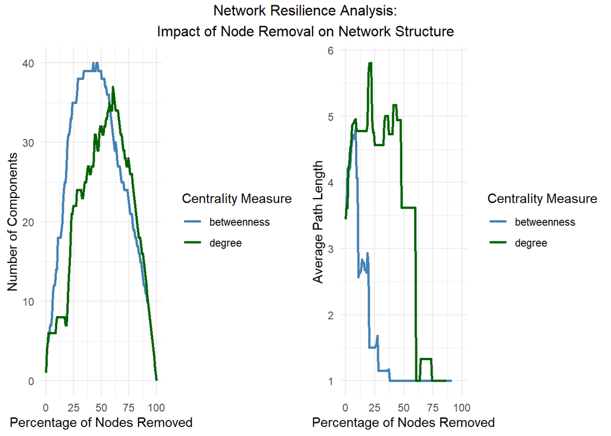

```r
# analyze notwork breakdown
analyze_network_breakdown <- function(g, removal_method = c("degree", "betweenness")) {
  results <- data.frame()
  g_copy <- g
  n_nodes <- vcount(g)

  # Get nodes order based on centrality
  if(removal_method == "degree") {
    nodes_order <- names(sort(degree(g), decreasing = TRUE))
  } else {
    nodes_order <- names(sort(betweenness(g), decreasing = TRUE))
  }

  # Add initial state
  components_count <- components(g_copy)$no
  avg_path <- mean_distance(g_copy)

  results <- rbind(results, data.frame(
    node_name = "Initial Network",
    percent_removed = 0,
    n_components = components_count,
    avg_distance = avg_path,
    method = removal_method
  ))

  # Remove nodes sequentially
  for(i in 1:length(nodes_order)) {
    current_node <- nodes_order[i]
    g_copy <- delete_vertices(g_copy, current_node)

    # Calculate metrics after removal
    components_count <- components(g_copy)$no

    # Safely calculate average path length
    if(is_connected(g_copy)) {
      avg_path <- mean_distance(g_copy)
    } else {
      comps <- decompose(g_copy)
      if(length(comps) > 0) {
        comp_sizes <- sapply(comps, vcount)
        largest_comp <- comps[[which.max(comp_sizes)]]
        if(vcount(largest_comp) > 1) {
          avg_path <- mean_distance(largest_comp)
        } else {
          avg_path <- NA
        }
      } else {
        avg_path <- NA
      }
    }

    results <- rbind(results, data.frame(
      node_name = current_node,
      percent_removed = i/n_nodes * 100,
      n_components = components_count,
      avg_distance = avg_path,
      method = removal_method
    ))
  }

  return(results)
}

# Generate results once to be used by both plots
degree_results <- analyze_network_breakdown(network_graph, "degree")
betweenness_results <- analyze_network_breakdown(network_graph, "betweenness")
all_results <- rbind(degree_results, betweenness_results)

# Create improved plots
p1 <- ggplot(all_results, aes(x = percent_removed, y = n_components,
                             color = method, linetype = method)) +
  geom_line(size = 1) +
  scale_color_manual(values = c("steelblue", "darkgreen")) +
  scale_linetype_manual(values = c("solid", "solid")) +
  labs(x = "Percentage of Nodes Removed",
       y = "Number of Components",
       color = "Centrality Measure",
       linetype = "Centrality Measure") +
  theme_minimal()

p2 <- ggplot(all_results, aes(x = percent_removed, y = avg_distance,
                             color = method, linetype = method)) +
  geom_line(size = 1) +
  scale_color_manual(values = c("steelblue", "darkgreen")) +
  scale_linetype_manual(values = c("solid", "solid")) +
  labs(x = "Percentage of Nodes Removed",
       y = "Average Path Length",
       color = "Centrality Measure",
       linetype = "Centrality Measure") +
  theme_minimal()

# Combine plots
grid.arrange(p1, p2, ncol = 2,
             top = "Network Resilience Analysis:\nImpact of Node Removal on Network Structure")
```

Fig.6.Network Resilience Analysis:of Node Removal on Network Structure

[figure not shown]

```r
# Generate Network Components Change plot
plot_components_change <- function(degree_results, betweenness_results) {
  p1 <- ggplot() +
    geom_line(data = degree_results[1:11,],
              aes(x = factor(node_name, levels = node_name), y = n_components, group = 1)) +
    geom_point(data = degree_results[1:11,],
               aes(x = factor(node_name, levels = node_name), y = n_components)) +
    scale_y_continuous(limits = c(0, 7)) +
    theme_minimal() +
    theme(axis.text.x = element_text(angle = 45, hjust = 1)) +
    labs(title = "a. Degree Centrality Based Removal",
         x = "Node Removal Sequence",
         y = "Number of Components")

  p2 <- ggplot() +
    geom_line(data = betweenness_results[1:11,],
              aes(x = factor(node_name, levels = node_name), y = n_components, group = 1)) +
    geom_point(data = betweenness_results[1:11,],
               aes(x = factor(node_name, levels = node_name), y = n_components)) +
    scale_y_continuous(limits = c(0, 7)) +
    theme_minimal() +
    theme(axis.text.x = element_text(angle = 45, hjust = 1)) +
    labs(title = "b. Betweenness Centrality Based Removal",
         x = "Node Removal Sequence",
         y = "Number of Components")

  grid.arrange(p1, p2, ncol = 2,
               top = "Network Components Change with Node Removal")
}



# For Network Components Change:
plot_components_change(degree_results, betweenness_results)
```

Fig.7.Network Components Change with Node Removal

# 5. Discussion

## 5.1 Challenges and Opportunities in Submarine Cable Network Development

From the above analysis, it can be concluded that the global submarine cable network faces significant challenges. Centrality analysis and vulnerability analysis show that major countries such as France and the United States have a large number of cable connections, and the network will become over-dependent on these key countries, and this connection will actually increase the network vulnerability. When these highly connected nodes fail, the number of connected components in the network increases rapidly, indicating severe disruptions in global connectivity.

While there are many more cables under construction, such as the Humboldt submarine cable, the real question is whether these developments are really addressing the structural imbalances in the global network, and will they exacerbate existing patterns of digital inequality? For example, while Europe benefits from dense cable coverage and fast data transmission, many developing regions must route their communications through distant hubs, resulting in higher costs and potential delays. Finding ways to maintain the efficiency of the main communication centers while developing more distributed regional networks to ensure reliable access and network resilience for all regions is an important challenge.

## 5.2 Research Limitations

# 6. Word Count

```
## Total word count (excluding code blocks): 3252
```

# 7. reference

Franken, J., Reinhold, T., Reichert, L., & Reuter, C. (2022). The digital divide in state vulnerability to submarine communications cable failure. *International Journal of Critical Infrastructure Protection*, *38*, 100522. Retrieved from https://www.sciencedirect.com/science/article/pii/S1874548222000130

Ganz, A., Camellini, M., Hine, E., Novelli, C., Roberts, H., & Floridi, L. (2024). Submarine Cables and the Risks to Digital Sovereignty. *Minds and Machines*, *34*(3), 31. Retrieved from https://doi.org/10.1007/s11023-024-09683-z

Jenelius, E., & Mattsson, L.-G. (2015). Road network vulnerability analysis: Conceptualization, implementation and application. *Computers, Environment and Urban Systems*, *49*, 136–147. Retrieved from https://www.sciencedirect.com/science/article/pii/S0198971514000192

Kang, X., Ma, X., Feng, R., Shao, S., & Ma, X. (2024). Review of the Current Situation and Problems of Submarine Cable Laying Construction Technology. In D.-S. Jeng & D. Wan (Eds.), *Proceedings of 10th International Conference on Coastal and Ocean Engineering* (pp. 129–143). Singapore: Springer Nature Singapore.

Marzo, J. L., Calle, E., Cosgaya, S. G., Rueda, D., & Mañosa, A. (2018). [On Selecting the Relevant Metrics of Network Robustness](https://doi.org/10.1109/RNDM.2018.8489809). *2018 10th International Workshop on Resilient Networks Design and Modeling (RNDM)* (pp. 1–7).

McGeachy, H. (2022). The changing strategic significance of submarine cables: Old technology, new concerns. *Australian Journal of International Affairs*, *76*(2), 161–177. Retrieved from https://doi.org/10.1080/10357718.2022.2051427

Msongaleli, D. L., Dikbiyik, F., Zukerman, M., & Mukherjee, B. (2015). [Disaster-aware submarine fiber-optic cable deployment](https://doi.org/10.1109/ONDM.2015.7127306). *2015 International Conference on Optical Network Design and Modeling (ONDM)* (pp. 245–250).

Wang, W., Yan, X., Li, S., Zhang, L., Ouyang, J., & Ni, X. (2021). Failure of submarine cables used in high-voltage power transmission: Characteristics, mechanisms, key issues and prospects. *IET Generation, Transmission & Distribution*, *15*(9), 1387–1402. Retrieved November 24, 2024, from https://doi.org/10.1049/gtd2.12117

章卓凡, 张维阳, 翟庆华, 钱雨昕, & 陈硕. (2022). 全球海底光缆传输网络的节点职能与鲁棒性评价. *世界地理研究*, *31*(5), 929–940.